# RML_project_US homocide

## 5.2 PROPORTIONAL PARITY

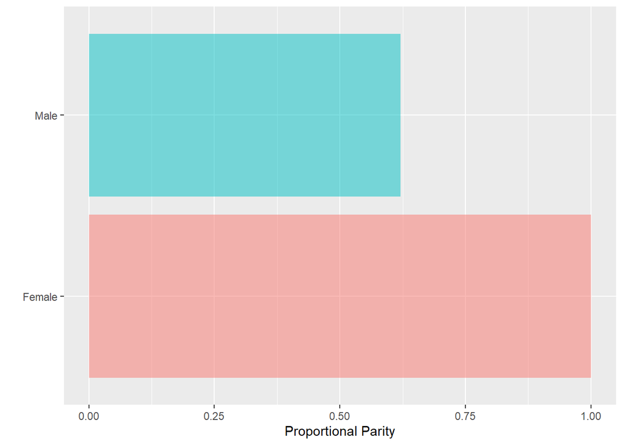

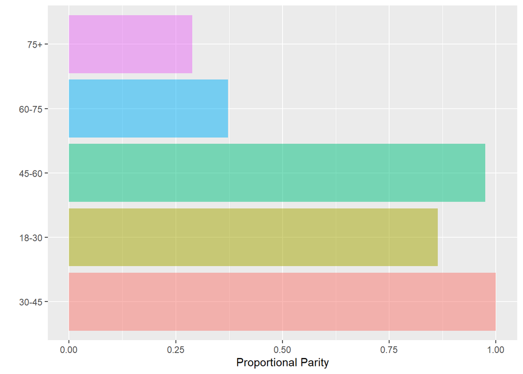

Proportional parity plot shows the proportion of all positively classified individuals in a given subgroup (positively classified means in this case that a crime was expected to be solved). In the cases of my analysis, the plots show that male had much smaller chances of their crimes to be solved. The same was true for older people, i.e. in age group categories 60-75 and particulary 75+.

## 5.3 EQUALIZED ODDS

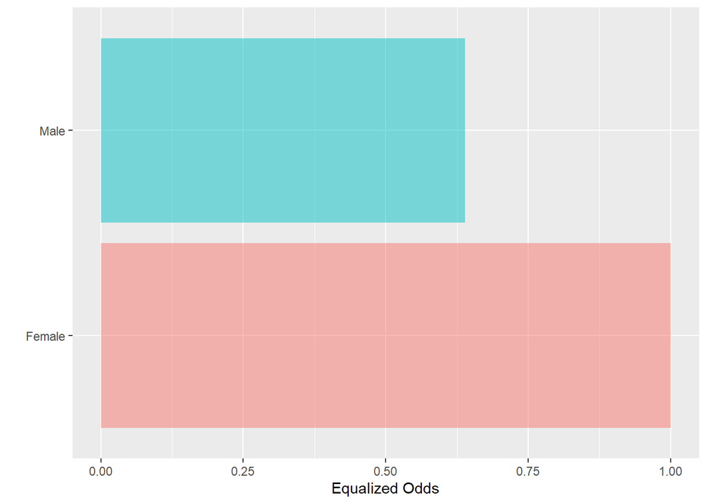

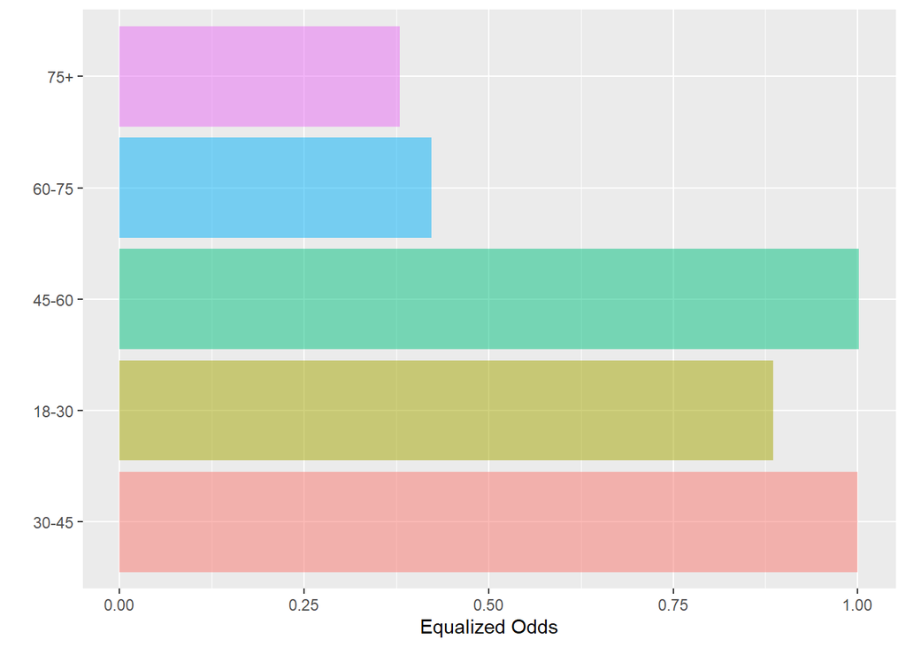

Equalized odds tell us basically how many true positive cases were correctly identified as a ratio of true positive cases and false negative cases. Equalized odds metrics confirm the proportional parity results. Males and older age groups were at disadvantage when it came to the expected chances of solving their crimes (i.e. crimes where they were victims).

# **6. SUMMARY**

The results of the analysis indicate that indeed a bias was to be observed as to whether a crime was solved or not. To the contrary of my expectation, the results do not provide any evidence of bias against race. In the end, the dataset was reduced to contain five "deep south" states, which were not known for their sympathy for ethnic minorities, especially in the 1980s decade.

Interestingly, the outcome of the analysis is an evidence of bias towards male and older people. These two social groups in multiple metrics are shown to be at considerable disadvantage when it comes to expected probabilites of solving crimes were these two subgroups were victims.